# Assignment3

Xiaoyao Yang

October 21, 2014

### Introduction

This article use ‘National Annenberg Election Survey 2008’ from The Annenberg Public Policy Center. This survey is a public opinion survey conducted via the Internet and designed to track the dynamics of political attitudes, perceptions, and behavior over the 2008 US primary and general presidential election campaigns. To be noted, The whole interview was segmented into five multi-month waves, numbered 1 – 5 and corresponding to the major divisions of the campaign: pre-primary, primary election, spring and summer, general election, and post-election.

A. One of main features of this survey is that many questions remained constant throughout the survey and were asked in multiple waves. So our goal here is try to see what kind of questions people tend to give different answers, and how this would affect final conclusion.

### 1. Data Preparation

First, read data. ‘dat_online_ttl’ contains five waves survey data.

```r
dat_online_ttl <- read.table('naes08-online-all-waves-data-compact.txt',sep='\t',header=TRUE)
dim(dat_online_ttl)
```

```
## [1] 28985  1227
```

### 2. Favorite Level Analysis Across Time (different waves)

Now, let’s visual our data!

Let’s create a function to see people’s favorite change acrossing five waves. The variable ‘ABp02_1’ to ‘ABo02_5’ represents favorite score for five waves. We can see that for Barack Obama, there is an obvious increase of favorite score between wave 4 and 5. Specifically, in wave 5, people tend to like Obama. While John McCain seems to have advantage in wave 4, people tend to feel just so so about him in wave 5. It is really interesting, do people feel good about Obama just for he won president campaign? One might need to figure out what happened between wave 4 and wave 5.

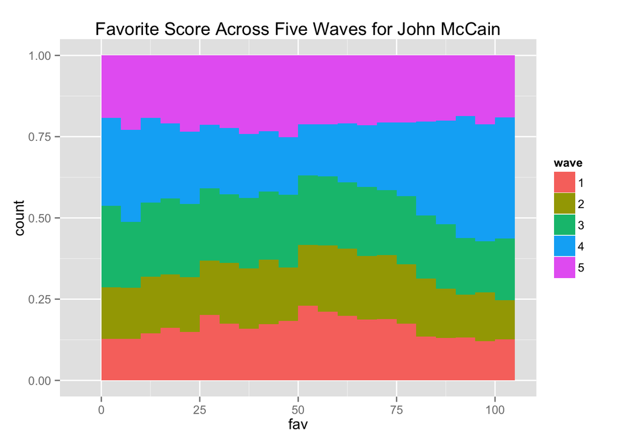

```r
#study favorite of specific person across different wave
fill_bar_favorite <- function(data=dat_online_ttl,
                              group_vars=c('ABo02_1','ABo02_2','ABo02_3','ABo02_4','ABo02_5'),
                              group_vars_name='wave',
                              value_name='fav',
                              group_vars_labels=c('1','2','3','4','5'),
                              titles='Favorite Score Across Five Waves'
){
  ##create ploting data
  plot_fav <-melt(data = data,id.vars=1,measure.vars=group_vars,
                  value.name='fav',variable.name='wave',na.rm = TRUE)
  plot_fav <- plot_fav[plot_fav$fav>=0 & plot_fav$fav<=100,]

  #see distribution
  if (length(group_vars)==1) {
    ggplot(data=plot_fav) + geom_histogram(aes(x = fav),binwidth=5) +
      ggtitle(titles) + xlab(value_name) + theme_bw()
  }
  else {
      ggplot(data=plot_fav) + geom_histogram(aes(x = fav,fill=wave),binwidth=5 ,position='fill') +
      scale_fill_discrete(name=group_vars_name,labels=group_vars_labels) +
    ggtitle(titles) + xlab(value_name)
  }
}


#plot
fill_bar_favorite(group_vars=c('AAm01_1','AAm01_2','AAm01_3','AAm01_4','AAm01_5'),
                  titles='Favorite Score Across Five Waves for John McCain')
```

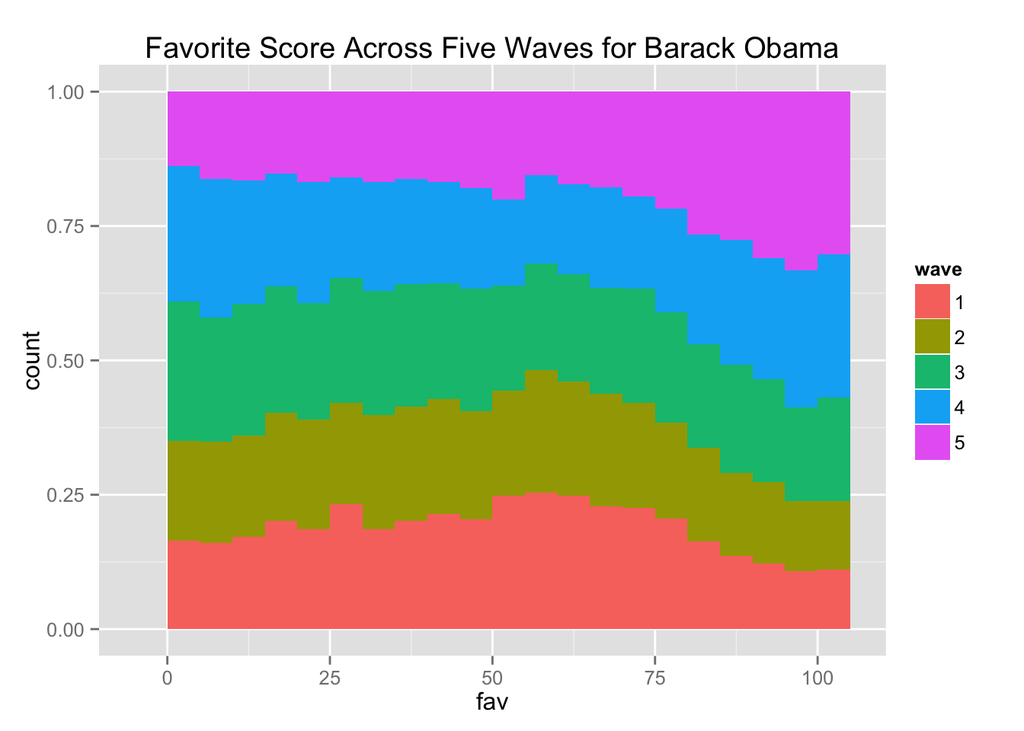

```r
fill_bar_favorite(titles='Favorite Score Across Five Waves for Barack Obama')
```

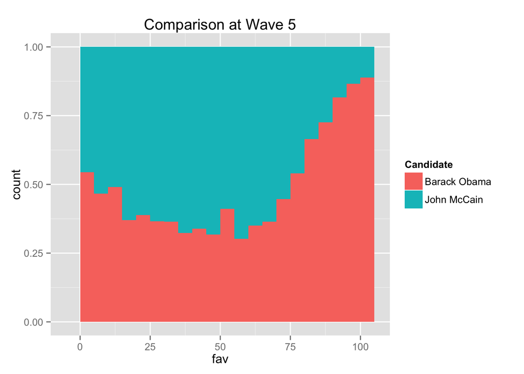

```r
fill_bar_favorite(group_vars=c('ABo02_5','AAm01_5'),group_vars_name='Candidate',group_vars_labels=c('Barack Obama','John McCain'),titles='Comparison at Wave 5')
```

### 3. Answers of similar questions in same Survey

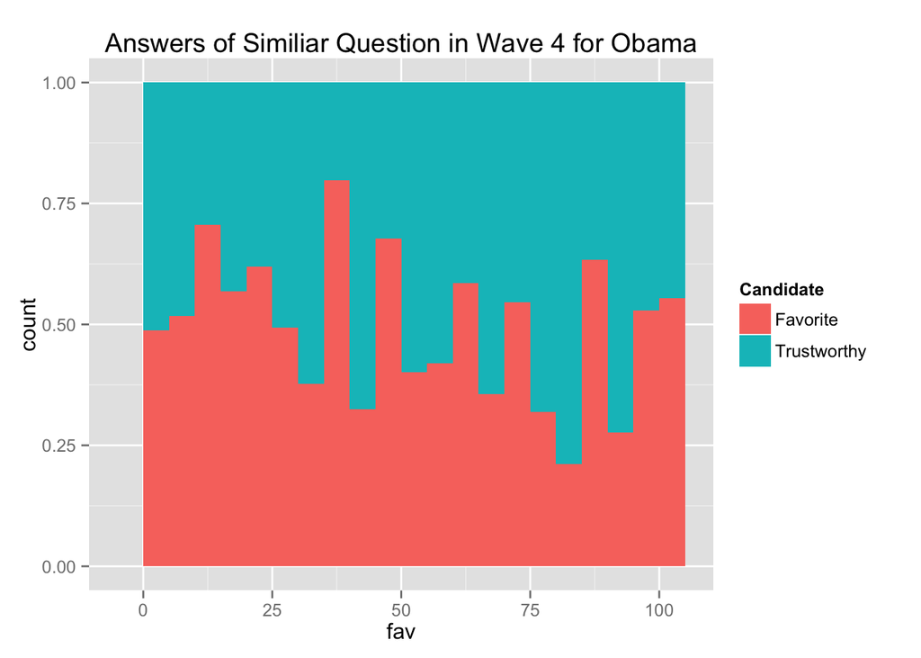

```r
fill_bar_favorite(group_vars=c('ABo06_4','ABo02_4'),group_vars_name='Candidate',group_vars_labels=c('Favorite','Trustworthy'),titles='Answers of Similiar Question in Wave 4 for Obama')
```

### 4. Visualization using Map

One might interested in how many respondent for each state, and further see the supporting rate for specific candidate of each state. To do this, we use ggplot2 and maps packages in R.

1. Mapping index -> state by using single file that generated from data description.
2. Calculate number of respondents by state(state is represented by number in original dataset) (response all 5 waves) and combine result with real state name.
3. Using ggplot2 to visualizing it!

Next, I try to put code into one function and basically what this function can do is to visualize any score by state, as long as we have a dataframe that have 56 index and 56 coresponding score. As an example, I visualize favorite score of Obama by state.

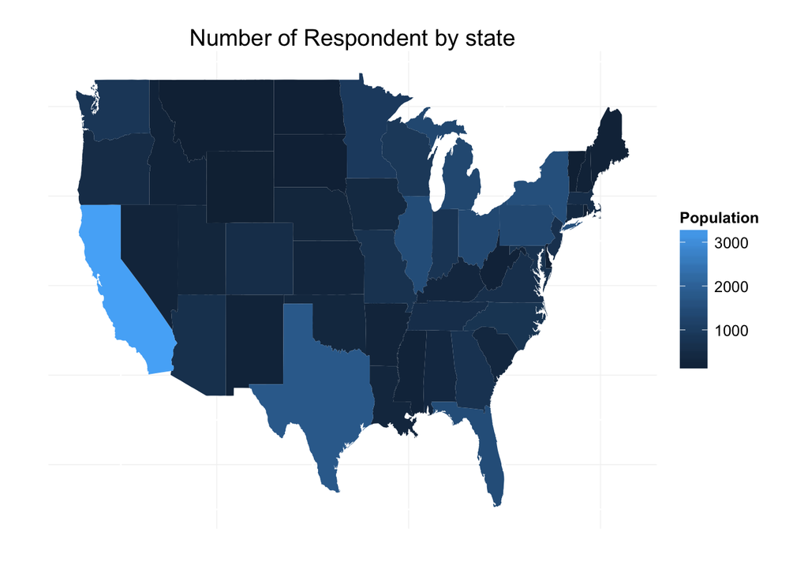

```r
#prepare population data
Heat_map <- function(var_by_state=count(dat_online_ttl$WFc01_a),
                                        var_name='Population',
                                        map_title='Number of Respondent by state'){
population <- var_by_state
names(population) <- c('index','Population')
states <- map_data("state")
state_name <- read.table('state_name.csv',sep=',',stringsAsFactors = F)
names(state_name) <- c('index','region')
state_name$region <- tolower(str_replace_all(state_name$region,pattern = ' \\(.+?\\)',replacement = ''))
population <- join(population,state_name,by='index')
##draw map
choro <- merge(states, population, sort = FALSE, by = "region")
choro <- choro[order(choro$order), ]
qplot(long, lat, data = choro, group = group, fill = Population,
  geom = "polygon",main=map_title,xlab='',ylab='') +
  theme(panel.background = element_blank(),axis.text = element_blank(),
        axis.ticks =element_blank()) +
  scale_fill_continuous(name=var_name)

}

Heat_map()
```

```r
#Visual fav_score by map
fav_score_w4_Obama <- aggregate(data=dat_online_ttl,ABo02_4 ~ WFc01_a,mean,na.omit=TRUE)
head(fav_score_w4_Obama)
```

```
##   WFc01_a  ABo02_4
## 1       1 43.35160
## 2       2 40.10256
## 3       4 47.04276
## 4       5 41.15068
## 5       6 55.59029
## 6       8 47.25208
```

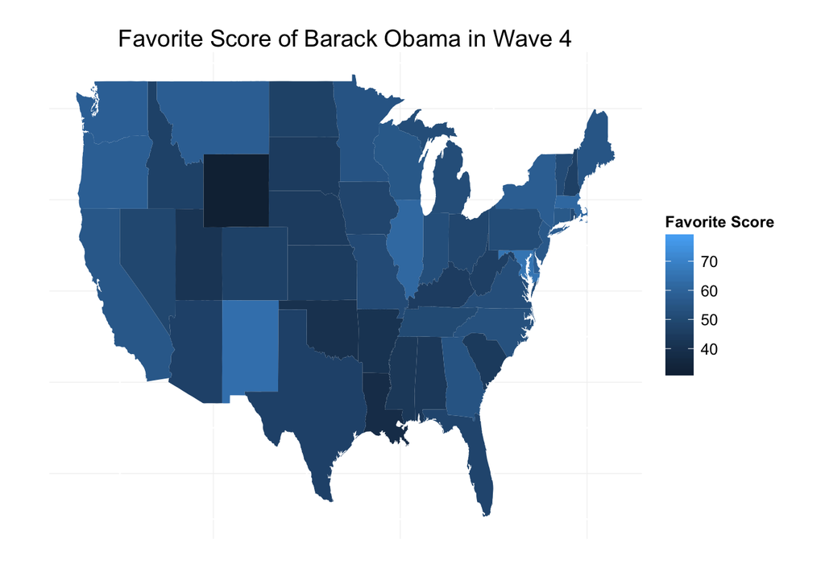

```r
Heat_map(var_by_state = fav_score_w4_Obama,var_name = 'Favorite Score',
         map_title = 'Favorite Score of Barack Obama in Wave 4')
```

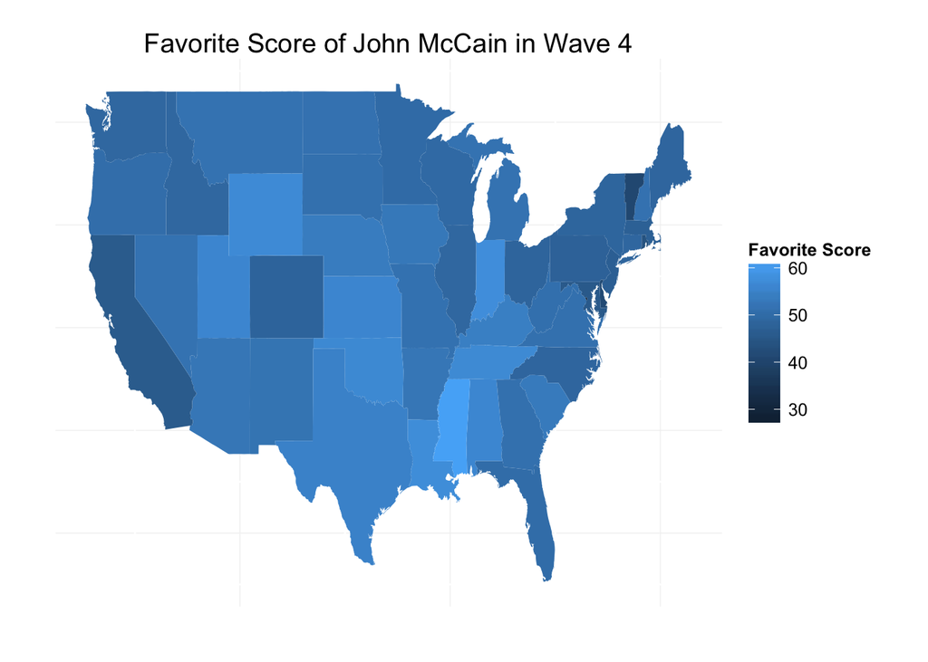

```r
fav_score_w4_Jm <- aggregate(data=dat_online_ttl,AAm01_4 ~ WFc01_a,mean,na.omit=TRUE)
Heat_map(var_by_state = fav_score_w4_Jm,var_name = 'Favorite Score',
         map_title = 'Favorite Score of John McCain in Wave 4')
```